# Aula de laboratório - Diferenças em diferenças

Autor

Rafael Bressan

Data de Publicação

16 de fevereiro de 2024

```python
import wooldridge as woo
import statsmodels.formula.api as smf
import numpy as np
import pandas as pd
```

Nesta aula vamos fazer uso do `R`, além de `Python`. Não encontrei nenhuma maneira razoavelmente simples de fazer **estudos de eventos** em Python, portanto, para esta parte da aula iremos recorrer ao `R`.

```r
library(lfe)
library(modelsummary)
library(did)
library(tidyverse)
```

## Diferenças em diferenças (DID)

Modelos DID são atualmente os mais utilizados em estudos observacionais para investigar os efeitos de alguma política em uma variável de interesse. Este tipo de *design* faz uso das variações tanto entre grupo de indivíduos quanto no tempo para obter o **efeito médio do tratamento sobre os tratados** - ATT.

$$\begin{align}
DID &= \underbrace{\mathbb{E}[Y_{ist}|s = \text{NJ}, t = \text{Nov}] - \mathbb{E}[Y_{ist}|s = \text{NJ}, t = \text{Fev}]}_{\Delta_t^{GT}}
- \Big(\underbrace{\mathbb{E}[Y_{ist}|s = \text{PA},t = \text{Nov}] - \mathbb{E}[Y_{ist}| s = \text{PA},t = \text{Fev}]}_{\Delta_t^{GC}}\Big) \\
\end{align}$$

onde estamos fazendo uso do exemplo Card e Krueger (1994). Pensilvânia (PA) é o estado de controle e Nova Jersey (NJ) o grupo tratado.

Em um formato de regressão, o estimador DID é obtido regredindo a variável de interesse em uma *dummy* para o grupo tratamento, uma outra *dummy* para o período após a intervenção e um termo de interação entre os dois, que denota o efetivo tratamento.

$$Y_{st} = \alpha + \beta TRAT_s + \gamma POS_t + \delta(TRAT_s \times POS_t) + \varepsilon_{st}$$

Nesta especificação $\hat\delta = \text{DID}$ e a vantagem de fazer a regressão é que podemos fazer inferência sobre o parâmetro estimado diretamente.

Vamos fazer um exemplo encontrado no livro-texto do Wooldridge, exemplo 13.3 os efeitos de um incinerador de lixo no preço das moradias.

```python
kielmc = woo.dataWoo("kielmc")
# DID manual
tratados = kielmc[kielmc["nearinc"] == 1]
controles = kielmc[kielmc["nearinc"] == 0]

delta_t = (
    tratados[tratados["year"] == 1981]["rprice"].mean()
    - tratados[tratados["year"] == 1978]["rprice"].mean()
)
delta_c = (
    controles[controles["year"] == 1981]["rprice"].mean()
    - controles[controles["year"] == 1978]["rprice"].mean()
)

did_manual = delta_t - delta_c
did_manual
```

```
-11863.903252112592
```

**Estime o efeito com um DID em forma de regressão**

```python
did_reg = smf.ols("rprice ~ nearinc * y81", data=kielmc).fit(cov_type="HC1")
did_reg.summary()
```

OLS Regression Results

| Dep. Variable: | rprice | R-squared: | 0.174 |
| --- | --- | --- | --- |
| Model: | OLS | Adj. R-squared: | 0.166 |
| Method: | Least Squares | F-statistic: | 17.75 |
| Date: | seg, 19 fev 2024 | Prob (F-statistic): | 1.13e-10 |
| Time: | 09:23:30 | Log-Likelihood: | -3765.2 |
| No. Observations: | 321 | AIC: | 7538. |
| Df Residuals: | 317 | BIC: | 7554. |
| Df Model: | 3 |  |  |
| Covariance Type: | HC1 |  |  |

|  | coef | std err | z | P>\|z\| | [0.025 | 0.975] |
| --- | --- | --- | --- | --- | --- | --- |
| Intercept | 8.252e+04 | 1882.391 | 43.836 | 0.000 | 7.88e+04 | 8.62e+04 |
| nearinc | -1.882e+04 | 5996.470 | -3.139 | 0.002 | -3.06e+04 | -7071.505 |
| y81 | 1.879e+04 | 3498.376 | 5.371 | 0.000 | 1.19e+04 | 2.56e+04 |
| nearinc:y81 | -1.186e+04 | 8635.585 | -1.374 | 0.169 | -2.88e+04 | 5061.533 |

| Omnibus: | 192.562 | Durbin-Watson: | 1.557 |
| --- | --- | --- | --- |
| Prob(Omnibus): | 0.000 | Jarque-Bera (JB): | 2462.071 |
| Skew: | 2.217 | Prob(JB): | 0.00 |
| Kurtosis: | 15.822 | Cond. No. | 6.05 |

Notes:  
[1] Standard Errors are heteroscedasticity robust (HC1)

Digamos que a hipótese de tendências paralelas seja válida somente após controlar pela idade do imóvel e idade ao quadrado, distância para uma rodovia, área do terreno e da moradia, número de quartos e banheiros.

Gostaríamos também que o modelo fosse especificado em logarítimos, para ter uma ideia de variação percentual do preço da moradia em relação a presença do incinerador.

**Calcule o efeito no cenário acima descrito**

**Código**

```python
did_ctr = smf.ols(
    "np.log(rprice) ~ nearinc * y81 + age + agesq + lintst + np.log(land) + np.log(area) + rooms + baths",
    data=kielmc
).fit(cov_type="HC1")
did_ctr.summary()
```

OLS Regression Results

| Dep. Variable: | np.log(rprice) | R-squared: | 0.733 |
| --- | --- | --- | --- |
| Model: | OLS | Adj. R-squared: | 0.724 |
| Method: | Least Squares | F-statistic: | 99.34 |
| Date: | seg, 19 fev 2024 | Prob (F-statistic): | 1.83e-90 |
| Time: | 09:23:30 | Log-Likelihood: | 60.690 |
| No. Observations: | 321 | AIC: | -99.38 |
| Df Residuals: | 310 | BIC: | -57.89 |
| Df Model: | 10 |  |  |
| Covariance Type: | HC1 |  |  |

|  | coef | std err | z | P>\|z\| | [0.025 | 0.975] |
| --- | --- | --- | --- | --- | --- | --- |
| Intercept | 7.6518 | 0.526 | 14.542 | 0.000 | 6.620 | 8.683 |
| nearinc | 0.0322 | 0.063 | 0.509 | 0.611 | -0.092 | 0.156 |
| y81 | 0.1621 | 0.027 | 5.951 | 0.000 | 0.109 | 0.215 |
| nearinc:y81 | -0.1315 | 0.060 | -2.195 | 0.028 | -0.249 | -0.014 |
| age | -0.0084 | 0.002 | -5.290 | 0.000 | -0.011 | -0.005 |
| agesq | 3.763e-05 | 1.05e-05 | 3.581 | 0.000 | 1.7e-05 | 5.82e-05 |
| lintst | -0.0614 | 0.035 | -1.756 | 0.079 | -0.130 | 0.007 |
| np.log(land) | 0.0998 | 0.033 | 3.041 | 0.002 | 0.035 | 0.164 |
| np.log(area) | 0.3508 | 0.062 | 5.653 | 0.000 | 0.229 | 0.472 |
| rooms | 0.0473 | 0.017 | 2.760 | 0.006 | 0.014 | 0.081 |
| baths | 0.0943 | 0.028 | 3.352 | 0.001 | 0.039 | 0.149 |

| Omnibus: | 67.368 | Durbin-Watson: | 1.710 |
| --- | --- | --- | --- |
| Prob(Omnibus): | 0.000 | Jarque-Bera (JB): | 356.631 |
| Skew: | -0.734 | Prob(JB): | 3.62e-78 |
| Kurtosis: | 7.951 | Cond. No. | 1.83e+05 |

Notes:  
[1] Standard Errors are heteroscedasticity robust (HC1)  
[2] The condition number is large, 1.83e+05. This might indicate that there are  
strong multicollinearity or other numerical problems.

# Efeito dos eventos climáticos costeiros nos preços das casas

Especificamente, analisaremos o efeito da temporada de furacões no Atlântico de 2005, que foi a temporada de furacões mais ativa registrada na história até 2020. Construiremos uma regressão simples de Diferença em Diferenças para estudar o efeito da temporada de furacões de 2005 na mudança no Índice de Preços de Imóveis, também conhecido como inflação de preços de imóveis nos estados costeiros.

Na nossa pequena experiência, o “tratamento” significará ser submetido a todo o impacto da temporada de furacões de 2005. A ‘unidade’ submetida (ou não) ao tratamento é um estado dos EUA com costa marítima. Existem 24 destes estados.

Decidiremos se um estado se enquadra no grupo de tratamento examinando as ações tomadas pela Agência Federal de Gestão de Emergências dos EUA (FEMA) naquele estado durante a temporada de furacões no Atlântico de 2005. Tentaremos resolver esta questão traçando a reta na mediana das contagens de condados que obtiveram auxílio. Qualquer estado com contagem maior ou igual à mediana (14) cairá no grupo de tratamento. O restante fará parte do grupo controle. Esta é a aparência do mapa do grupo:

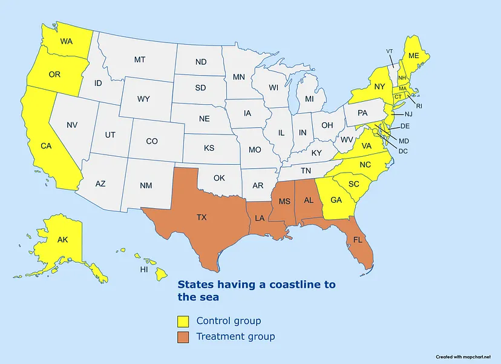

Vamos carregar os dados:

```python
df = pd.read_csv("data/us_fred_coastal_us_states.csv", header=0)
df.head()
```

```
         STATE   HPI_CHG  ...  NUM_DISASTERS  NUM_IND_ASSIST
0  GASTHPI_CHG  0.014009  ...              1               0
1  NCSTHPI_CHG  0.014221  ...              3               0
2  TXSTHPI_CHG  0.010192  ...              5              22
3  MASTHPI_CHG  0.027537  ...              4               9
4  ALSTHPI_CHG  0.017585  ...              4              14

[5 rows x 6 columns]
```

Nossa variável dependente será `HPI_CHG`, que é a variação percentual no índice de preços de imóveis. Nossos regressores serão as *dummies* `Time_Period` e `Disaster_Affected`, onde a primeira reflete o período de intempéries e a última indica se o estado foi afetado por desastres naturais em 2005 acima da mediana de condados que obtiveram auxílio.

**Especifique e estime a regressão DID**

```python
# | code-fold: true
did_reg = smf.ols("HPI_CHG ~ Time_Period * Disaster_Affected", data=df).fit(
    cov_type="HC1"
)
did_reg.summary()
```

OLS Regression Results

| Dep. Variable: | HPI_CHG | R-squared: | 0.536 |
| --- | --- | --- | --- |
| Model: | OLS | Adj. R-squared: | 0.504 |
| Method: | Least Squares | F-statistic: | 17.83 |
| Date: | seg, 19 fev 2024 | Prob (F-statistic): | 1.02e-07 |
| Time: | 09:23:30 | Log-Likelihood: | 145.14 |
| No. Observations: | 48 | AIC: | -282.3 |
| Df Residuals: | 44 | BIC: | -274.8 |
| Df Model: | 3 |  |  |
| Covariance Type: | HC1 |  |  |

|  | coef | std err | z | P>\|z\| | [0.025 | 0.975] |
| --- | --- | --- | --- | --- | --- | --- |
| Intercept | 0.0371 | 0.003 | 11.259 | 0.000 | 0.031 | 0.044 |
| Time_Period | -0.0278 | 0.004 | -7.242 | 0.000 | -0.035 | -0.020 |
| Disaster_Affected | -0.0139 | 0.009 | -1.532 | 0.125 | -0.032 | 0.004 |
| Time_Period:Disaster_Affected | 0.0197 | 0.010 | 2.067 | 0.039 | 0.001 | 0.038 |

| Omnibus: | 5.463 | Durbin-Watson: | 1.165 |
| --- | --- | --- | --- |
| Prob(Omnibus): | 0.065 | Jarque-Bera (JB): | 4.279 |
| Skew: | 0.623 | Prob(JB): | 0.118 |
| Kurtosis: | 3.767 | Cond. No. | 6.78 |

Notes:  
[1] Standard Errors are heteroscedasticity robust (HC1)

O efeito do tratamento é **positivo** e estatisticamente significativo (i.e. 1,97 p.p). Isso significa que a inflação dos preços das casas foi maior nos estados costeiros que foram afetados por desastres naturais em 2005 em relação aos estados também costeiros mas que não foram tão fortemente impactados.

- Qual a racionalização econômica que você daria para este resultado?

# Replicando Cheng and Hoekstra (2013), quase 😄

Cheng e Hoekstra (2013) avaliaram o impacto que uma reforma de armas teve sobre a violência e para ilustrar vários princípios e práticas em relação ao timing diferencial. Vamos discutir esses princípios no contexto deste artigo.

Considerando que antes a autodefesa letal era legal apenas dentro de casa, uma nova lei, “Stand Your Ground”, estendeu esse direito a outros locais públicos. Entre 2000 e 2010, vinte e um estados expandiram explicitamente o estatuto da doutrina do castelo, estendendo os locais fora de casa onde a força letal poderia ser usada legalmente.

Cheng e Hoekstra (2013) escolheram um projeto de diferença em diferenças para seu projeto, onde a lei da doutrina do castelo era o tratamento e o tempo era diferenciado entre os estados. Sua equação de estimativa foi:

$$Y_{it}=\alpha+\delta D_{it}+\gamma X_{it}+\sigma_i+\tau_t+\varepsilon_{it}$$

Cheng e Hoekstra (2013) não encontraram evidências de que as leis da doutrina do castelo dissuadissem ofensas violentas, mas descobriram que isso aumentava os homicídios. Um aumento líquido de 8% nas taxas de homicídios se traduz em cerca de seiscentos homicídios adicionais por ano nos vinte e um estados que o adotaram.

```r
read_data <- function(df) {
    full_path <- paste("https://raw.github.com/scunning1975/mixtape/master/",
        df,
        sep = ""
    )
    df <- haven::read_dta(full_path)
    return(df)
}

castle <- read_data("castle.dta")

#--- global variables
crime1 <- c(
    "jhcitizen_c", "jhpolice_c",
    "murder", "homicide",
    "robbery", "assault", "burglary",
    "larceny", "motor", "robbery_gun_r"
)
# demographics
demo <- c(
    "emo", "blackm_15_24", "whitem_15_24",
    "blackm_25_44", "whitem_25_44"
)
# variables dropped to prevent colinearity
dropped_vars <- c(
    "r20004", "r20014",
    "r20024", "r20034",
    "r20044", "r20054",
    "r20064", "r20074",
    "r20084", "r20094",
    "r20101", "r20102", "r20103",
    "r20104", "trend_9", "trend_46",
    "trend_49", "trend_50", "trend_51"
)
# Trend columns to keep
lintrend <- castle %>%
    select(starts_with("trend")) %>%
    colnames() %>%
    # remove due to colinearity
    subset(., !. %in% dropped_vars)
# Region columns to keep
region <- castle %>%
    select(starts_with("r20")) %>%
    colnames() %>%
    # remove due to colinearity
    subset(., !. %in% dropped_vars)
exocrime <- c("l_lacerny", "l_motor")
spending <- c("l_exp_subsidy", "l_exp_pubwelfare")
xvar <- c(
    "blackm_15_24", "whitem_15_24", "blackm_25_44", "whitem_25_44",
    "l_exp_subsidy", "l_exp_pubwelfare",
    "l_police", "unemployrt", "poverty",
    "l_income", "l_prisoner", "l_lagprisoner"
)
law <- c("cdl")
```

Por exemplo, vamos conferir a evolução dos homicídios na Florida (sid = 10) contra a Califórnia (sid = 5)

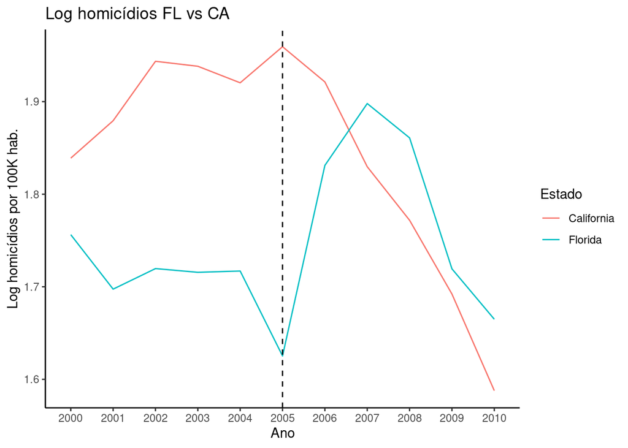

```r
fl_ca <- castle |>
    filter(sid %in% c(5, 10)) |>
    mutate(
        sid = as.factor(sid),
        year_fct = as.factor(year)
    )

ggplot(fl_ca, aes(year_fct, l_homicide, group = sid, color = sid)) +
    geom_line() +
    scale_color_discrete(labels = c("California", "Florida")) +
    geom_vline(xintercept = "2005", linetype = 2) +
    labs(
        x = "Ano",
        y = "Log homicídios por 100K hab.",
        title = "Log homicídios FL vs CA"
    ) +
    guides(color = guide_legend(title = "Estado")) +
    theme_classic()
```

Vamos conferir também quais estados passaram este tipo de lei e quando

```r
cdl_sid <- castle |>
    group_by(sid, state) |>
    summarise(sum_post = sum(post)) |>
    filter(sum_post > 0) |>
    pull(sid)
```

[output not shown]

```r
cdl_states <- castle |>
    select(sid, state, year, post) |>
    filter(sid %in% cdl_sid, post == 0) |>
    group_by(sid) |>
    slice(n()) |>
    arrange(year)
kableExtra::kbl(cdl_states[, c("state", "year")],
    col.names = c("Estado", "Ano CDL")
) |>
    kableExtra::kable_classic(full_width = FALSE)
```

| Estado | Ano CDL |
| --- | --- |
| Florida | 2005 |
| Alabama | 2006 |
| Alaska | 2006 |
| Arizona | 2006 |
| Georgia | 2006 |
| Indiana | 2006 |
| Kansas | 2006 |
| Kentucky | 2006 |
| Louisiana | 2006 |
| Michigan | 2006 |
| Mississippi | 2006 |
| Oklahoma | 2006 |
| South Carolina | 2006 |
| South Dakota | 2006 |
| Missouri | 2007 |
| North Dakota | 2007 |
| Tennessee | 2007 |
| Texas | 2007 |
| Ohio | 2008 |
| West Virginia | 2008 |
| Montana | 2009 |

Este tipo de design é o que chama-se de adoção escalonada ao tratamento (*staggered adoption*). Existem diversas coortes que aderem ao tratamento em momentos distintos

```r
dd_formula <- as.formula(
    paste(
        "l_homicide ~ ",
        paste(
            paste(xvar, collapse = " + "),
            paste(region, collapse = " + "),
            paste(lintrend, collapse = " + "),
            paste("post", collapse = " + "),
            sep = " + "
        ),
        "| year + sid | 0 | sid"
    )
)
# Fixed effect regression using post as treatment variable
dd_reg <- felm(dd_formula, weights = castle$popwt, data = castle)
msummary(dd_reg,
    output = "kableExtra",
    fmt = 4,
    coef_map = "post",
    gof_map = c("nobs", "adj.r.squared", "vcov.type")
) |>
    kableExtra::kable_classic()
```

|  | (1) |
| --- | --- |
| post | 0.0769 |
|  | (0.0336) |
| Num.Obs. | 550 |
| R2 Adj. | 0.951 |
| Std.Errors | by: sid |

Agora, vamos ir além do estudo deles e implementar um **estudo de evento**. Para fazer isso, usamos uma variável “time_til”, que é o número de anos até ou depois que o estado recebeu o tratamento. Usando essa variável, criamos os leads (que serão os anos anteriores ao tratamento) e os lags (os anos pós-tratamento). Felizmente o dataset providenciado já possui estas dummies.

```r
event_study_formula <- as.formula(
    paste(
        "l_homicide ~ + ",
        paste(
            paste(region, collapse = " + "),
            paste(paste("lead", 1:9, sep = ""), collapse = " + "),
            paste(paste("lag", 1:5, sep = ""), collapse = " + "),
            sep = " + "
        ),
        "| year + state | 0 | sid"
    ),
)

event_study_reg <- felm(event_study_formula, weights = castle$popwt, data = castle)
msummary(event_study_reg,
    output = "kableExtra",
    fmt = 4,
    coef_omit = "^(?!lead|lag)", # lookahed regex. starts with lead or lag
    gof_map = c("nobs", "adj.r.squared", "vcov.type")
) |>
    kableExtra::kable_classic()
```

|  | (1) |
| --- | --- |
| lead1 | -0.0255 |
|  | (0.0327) |
| lead2 | 0.0191 |
|  | (0.0308) |
| lead3 | 0.0122 |
|  | (0.0346) |
| lead4 | -0.0041 |
|  | (0.0461) |
| lead5 | 0.0050 |
|  | (0.0466) |
| lead6 | 0.0093 |
|  | (0.0590) |
| lead7 | -0.1372 |
|  | (0.0854) |
| lead8 | -0.3036 |
|  | (0.0808) |
| lead9 | -0.2607 |
|  | (0.0446) |
| lag1 | 0.0777 |
|  | (0.0279) |
| lag2 | 0.0824 |
|  | (0.0449) |
| lag3 | 0.1050 |
|  | (0.0524) |
| lag4 | 0.0787 |
|  | (0.0583) |
| lag5 | 0.1724 |
|  | (0.0554) |
| Num.Obs. | 550 |
| R2 Adj. | 0.932 |
| Std.Errors | by: sid |

É comum plotar esses estudos de eventos. Utiliza-se gráficos tipo point-range, onde a estimativa pontual e o intervalo de confiança são mostrados. Vamos fazer isso agora.

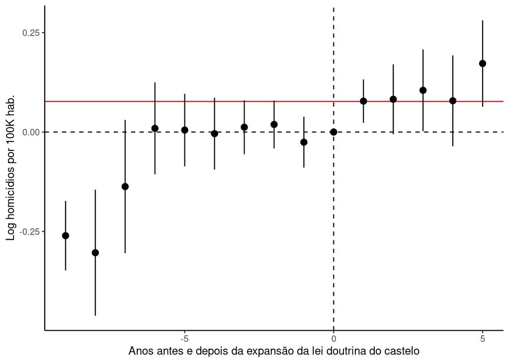

```r
# order of the coefficients for the plot
plot_order <- c(
    "lead9", "lead8", "lead7",
    "lead6", "lead5", "lead4", "lead3",
    "lead2", "lead1", "lag1",
    "lag2", "lag3", "lag4", "lag5"
)
# grab the clustered standard errors
# and average coefficient estimates
# from the regression, label them accordingly
# add a zero'th lag for plotting purposes
leadslags_plot <- tibble(
    sd = c(event_study_reg$cse[plot_order], 0),
    mean = c(coef(event_study_reg)[plot_order], 0),
    label = c(-9:-1, 1:5, 0)
)
# This version has a point-range at each
# estimated lead or lag
# comes down to stylistic preference at the
# end of the day!
leadslags_plot %>%
    ggplot(aes(
        x = label, y = mean,
        ymin = mean - 1.96 * sd,
        ymax = mean + 1.96 * sd
    )) +
    geom_hline(
        yintercept = coef(dd_reg)["post"],
        color = "red"
    ) +
    geom_pointrange() +
    theme_classic() +
    xlab("Anos antes e depois da expansão da lei doutrina do castelo") +
    ylab("Log homicídios por 100K hab.") +
    geom_hline(
        yintercept = 0,
        linetype = "dashed"
    ) +
    geom_vline(
        xintercept = 0,
        linetype = "dashed"
    )
```

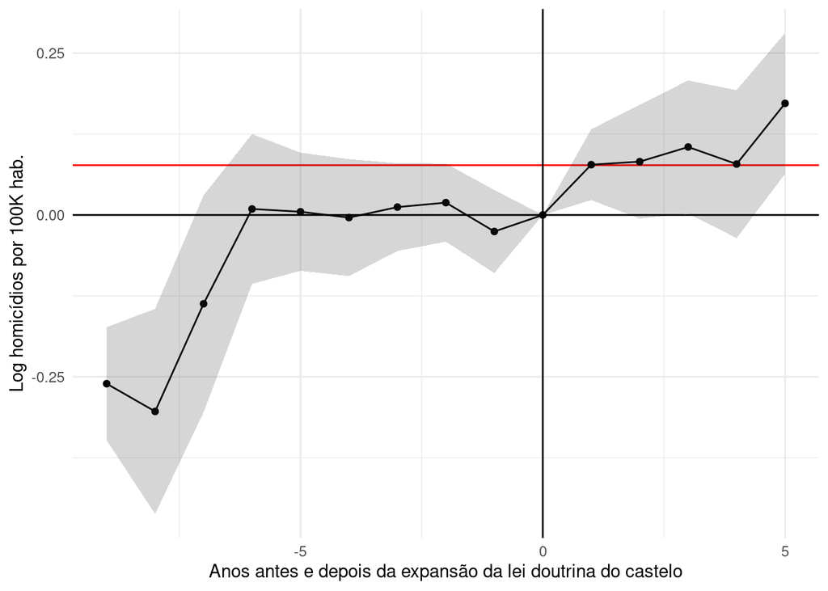

```r
# This version includes
# an interval that traces the confidence intervals
# of your coefficients
leadslags_plot %>%
    ggplot(aes(
        x = label, y = mean,
        ymin = mean - 1.96 * sd,
        ymax = mean + 1.96 * sd
    )) +
    # this creates a red horizontal line
    geom_hline(
        yintercept = coef(dd_reg)["post"],
        color = "red"
    ) +
    geom_line() +
    geom_point() +
    geom_ribbon(alpha = 0.2) +
    theme_minimal() +
    # Important to have informative axes labels!
    xlab("Anos antes e depois da expansão da lei doutrina do castelo") +
    ylab("Log homicídios por 100K hab.") +
    geom_hline(yintercept = 0) +
    geom_vline(xintercept = 0)
```

Uma literatura recente tem demonstrado que esta especificação pode ser viesada para o efeito do tratamento sobre os tratados, ou seja, TWFE com adocação escalonada pode não ser equivalente ao estimador de DID. Vamos utilizar a mesma especificação, porém utilizando o estimador de Callaway & Sant’anna encontrado no pacote `did`.

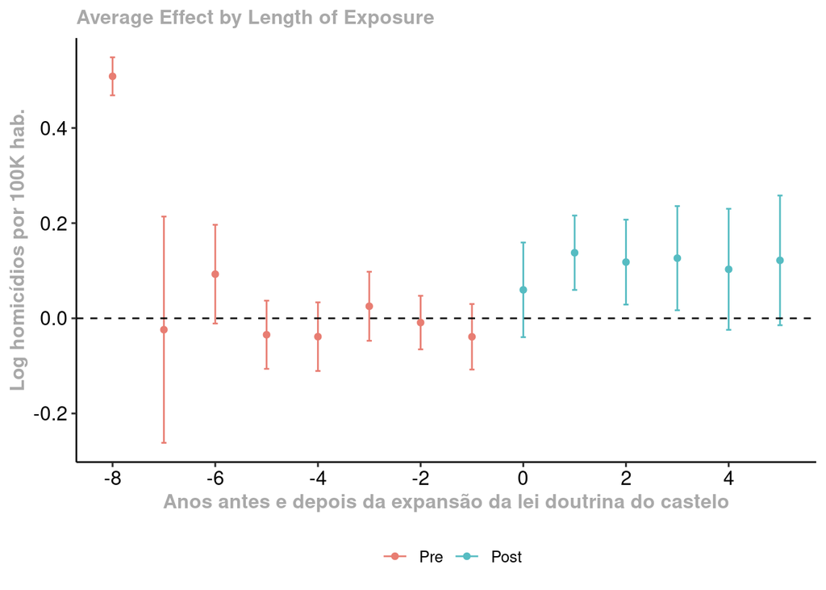

```r
# Precisamos adaptar o data.frame para a funcao att_gt
castle_cs <- replace_na(castle, list(effyear = 0)) |>
    select(sid, year, effyear, popwt, l_homicide, r20001)
did_gt <- att_gt(
    yname = "l_homicide",
    tname = "year",
    idname = "sid",
    gname = "effyear",
    weightsname = "popwt",
    # xformla = ~r20001,
    control_group = "notyettreated",
    data = castle_cs
)
did_es <- aggte(did_gt, type = "dynamic")

ggdid(did_es) +
    scale_x_continuous(n.breaks = 10) +
    labs(
        x = "Anos antes e depois da expansão da lei doutrina do castelo",
        y = "Log homicídios por 100K hab."
    )
```